# TEST 2

```python
import pandas as pd
import numpy as np
import matplotlib.pyplot as plt
import seaborn as sns
from sklearn.preprocessing import StandardScaler

%matplotlib inline
```

```python
df = pd.read_excel('Chemical Data_koti_SET_62.xlsx')
```

```python
df.head()
```

|  | BIOCHEMICAL PARAMETERS OF Acacia nilotica of site-2(koti) from nov 2009-oct 2011. | Unnamed: 1 | Unnamed: 2 | Unnamed: 3 | Unnamed: 4 | Unnamed: 5 | Unnamed: 6 | Unnamed: 7 | Unnamed: 8 | Unnamed: 9 | Unnamed: 10 | Unnamed: 11 | Unnamed: 12 | Unnamed: 13 | Unnamed: 14 | Unnamed: 15 |
| --- | --- | --- | --- | --- | --- | --- | --- | --- | --- | --- | --- | --- | --- | --- | --- | --- |
| 0 | NaT | TOT-CHL | PH | ASA | RWC | APTI | CARB | PROTEIN | RED-SUG | NON-RED SUGARS | STARCH | TOTAL SUG | PHENOLS | CAT | POD | PPO |
| 1 | 2015-11-09 | 0.86 | 0.86 | 1 | 87 | 9.38 | 61.98 | 36.9 | 0.51 | 3.47 | 50.83 | 3.98 | 67.1 | 632.5 | 95.4 | 225.6 |
| 2 | 2015-12-09 | 1.03 | 1.03 | 0.6 | 81 | 8.55 | 60.22 | 36.8 | 0.62 | 3.37 | 50.96 | 3.99 | 67.6 | 632.6 | 93.2 | 225.6 |
| 3 | 2015-01-10 | 0.82 | 0.82 | 0.5 | 80 | 8.36 | 62.12 | 36.8 | 0.61 | 3.26 | 50.96 | 3.87 | 67.3 | 632.5 | 93.1 | 225.5 |
| 4 | 2015-02-10 | 0.35 | 0.35 | 0.2 | 66 | 6.74 | 61.25 | 36.4 | 0.59 | 3.27 | 51.23 | 3.86 | 67.7 | 632.5 | 93 | 225.5 |

```python
df.columns = ['Date', 'TOT-CHL', 'PH', 'ASA', 'RWC', 'APTI', 'CARB',
             'PROTEIN', 'RED-SUG', 'NON-RED SUGARS', 'STARCH', 'TOTAL SUG'
            , 'PHENOLS', 'CAT', 'POD', 'PPO']
```

```python
df1 = df.drop(index=0)
```

```python
df1.head()
```

|  | Date | TOT-CHL | PH | ASA | RWC | APTI | CARB | PROTEIN | RED-SUG | NON-RED SUGARS | STARCH | TOTAL SUG | PHENOLS | CAT | POD | PPO |
| --- | --- | --- | --- | --- | --- | --- | --- | --- | --- | --- | --- | --- | --- | --- | --- | --- |
| 1 | 2015-11-09 | 0.86 | 0.86 | 1 | 87 | 9.38 | 61.98 | 36.9 | 0.51 | 3.47 | 50.83 | 3.98 | 67.1 | 632.5 | 95.4 | 225.6 |
| 2 | 2015-12-09 | 1.03 | 1.03 | 0.6 | 81 | 8.55 | 60.22 | 36.8 | 0.62 | 3.37 | 50.96 | 3.99 | 67.6 | 632.6 | 93.2 | 225.6 |
| 3 | 2015-01-10 | 0.82 | 0.82 | 0.5 | 80 | 8.36 | 62.12 | 36.8 | 0.61 | 3.26 | 50.96 | 3.87 | 67.3 | 632.5 | 93.1 | 225.5 |
| 4 | 2015-02-10 | 0.35 | 0.35 | 0.2 | 66 | 6.74 | 61.25 | 36.4 | 0.59 | 3.27 | 51.23 | 3.86 | 67.7 | 632.5 | 93 | 225.5 |
| 5 | 2015-03-10 | 0.62 | 0.62 | 0.4 | 60 | 6.28 | 62.14 | 36.6 | 0.6 | 3.27 | 51.24 | 3.87 | 67.2 | 632.4 | 93.4 | 225.4 |

```python
df1.to_csv('Data_1.csv')
```

```python
df = pd.read_csv('Data_1.csv')
```

```python
df.head()
```

|  | Unnamed: 0 | Date | TOT-CHL | PH | ASA | RWC | APTI | CARB | PROTEIN | RED-SUG | NON-RED SUGARS | STARCH | TOTAL SUG | PHENOLS | CAT | POD | PPO |
| --- | --- | --- | --- | --- | --- | --- | --- | --- | --- | --- | --- | --- | --- | --- | --- | --- | --- |
| 0 | 1 | 2015-11-09 | 0.86 | 0.86 | 1.0 | 87.0 | 9.38 | 61.98 | 36.9 | 0.51 | 3.47 | 50.83 | 3.98 | 67.1 | 632.5 | 95.4 | 225.6 |
| 1 | 2 | 2015-12-09 | 1.03 | 1.03 | 0.6 | 81.0 | 8.55 | 60.22 | 36.8 | 0.62 | 3.37 | 50.96 | 3.99 | 67.6 | 632.6 | 93.2 | 225.6 |
| 2 | 3 | 2015-01-10 | 0.82 | 0.82 | 0.5 | 80.0 | 8.36 | 62.12 | 36.8 | 0.61 | 3.26 | 50.96 | 3.87 | 67.3 | 632.5 | 93.1 | 225.5 |
| 3 | 4 | 2015-02-10 | 0.35 | 0.35 | 0.2 | 66.0 | 6.74 | 61.25 | 36.4 | 0.59 | 3.27 | 51.23 | 3.86 | 67.7 | 632.5 | 93.0 | 225.5 |
| 4 | 5 | 2015-03-10 | 0.62 | 0.62 | 0.4 | 60.0 | 6.28 | 62.14 | 36.6 | 0.60 | 3.27 | 51.24 | 3.87 | 67.2 | 632.4 | 93.4 | 225.4 |

```python
df.drop(['Unnamed: 0'], axis=1, inplace=True)
```

```python
df.head()
```

|  | Date | TOT-CHL | PH | ASA | RWC | APTI | CARB | PROTEIN | RED-SUG | NON-RED SUGARS | STARCH | TOTAL SUG | PHENOLS | CAT | POD | PPO |
| --- | --- | --- | --- | --- | --- | --- | --- | --- | --- | --- | --- | --- | --- | --- | --- | --- |
| 0 | 2015-11-09 | 0.86 | 0.86 | 1.0 | 87.0 | 9.38 | 61.98 | 36.9 | 0.51 | 3.47 | 50.83 | 3.98 | 67.1 | 632.5 | 95.4 | 225.6 |
| 1 | 2015-12-09 | 1.03 | 1.03 | 0.6 | 81.0 | 8.55 | 60.22 | 36.8 | 0.62 | 3.37 | 50.96 | 3.99 | 67.6 | 632.6 | 93.2 | 225.6 |
| 2 | 2015-01-10 | 0.82 | 0.82 | 0.5 | 80.0 | 8.36 | 62.12 | 36.8 | 0.61 | 3.26 | 50.96 | 3.87 | 67.3 | 632.5 | 93.1 | 225.5 |
| 3 | 2015-02-10 | 0.35 | 0.35 | 0.2 | 66.0 | 6.74 | 61.25 | 36.4 | 0.59 | 3.27 | 51.23 | 3.86 | 67.7 | 632.5 | 93.0 | 225.5 |
| 4 | 2015-03-10 | 0.62 | 0.62 | 0.4 | 60.0 | 6.28 | 62.14 | 36.6 | 0.60 | 3.27 | 51.24 | 3.87 | 67.2 | 632.4 | 93.4 | 225.4 |

# EDA

Exploratory Data Analysis

EDA is the process of figuring out what the data can tell us and we use EDA to find patterns, relationships, or anomalies to inform our subsequent analysis.

## Pair Plots

A pairs plot allows us to see both distribution of single variables and relationships between two variables.

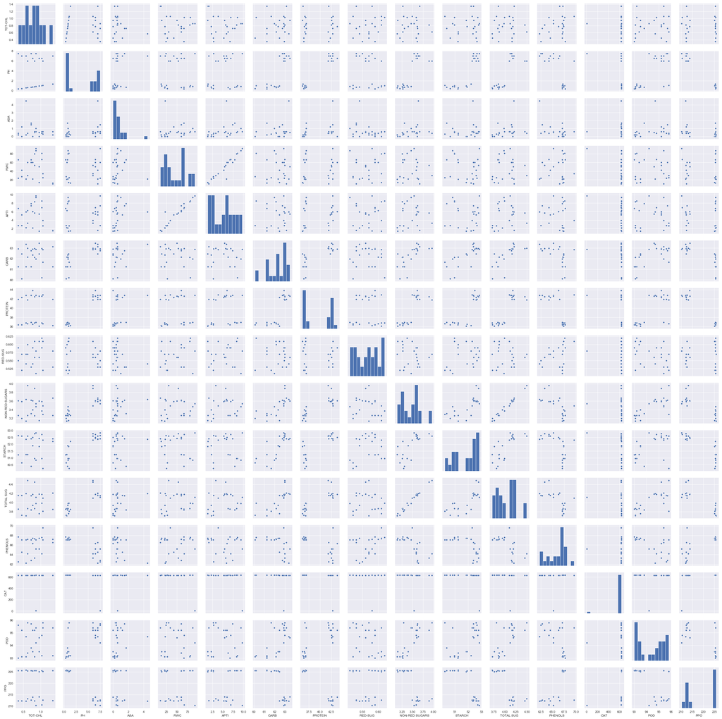

```python
sns.set(rc={'figure.figsize':(200,200)})
sns.pairplot(df)
```

## Heat Map

A heat map (or heatmap) is a graphical representation of data where the individual values contained in a matrix are represented as colors.

Correlation is a statistical technique that can show whether and how strongly pairs of variables are related.

The main result of a correlation is called the correlation coefficient (or "r"). It ranges from -1.0 to +1.0. The closer r is to +1 or -1, the more closely the two variables are related.

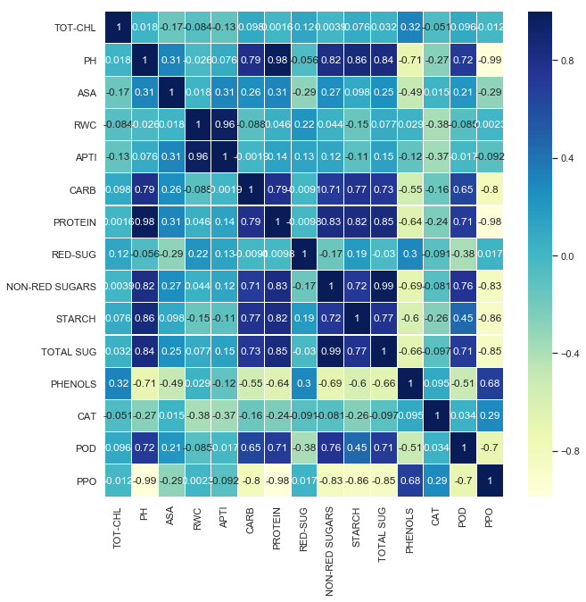

```python
f, ax = plt.subplots(figsize =(10, 10))
sns.heatmap(df.corr(), ax = ax, cmap ="YlGnBu", linewidths = 0.1, annot=True)
```

# Analysing w.r.t. TOT-CHL

```python
df.head()
```

|  | Date | TOT-CHL | PH | ASA | RWC | APTI | CARB | PROTEIN | RED-SUG | NON-RED SUGARS | STARCH | TOTAL SUG | PHENOLS | CAT | POD | PPO |
| --- | --- | --- | --- | --- | --- | --- | --- | --- | --- | --- | --- | --- | --- | --- | --- | --- |
| 0 | 2015-11-09 | 0.86 | 0.86 | 1.0 | 87.0 | 9.38 | 61.98 | 36.9 | 0.51 | 3.47 | 50.83 | 3.98 | 67.1 | 632.5 | 95.4 | 225.6 |
| 1 | 2015-12-09 | 1.03 | 1.03 | 0.6 | 81.0 | 8.55 | 60.22 | 36.8 | 0.62 | 3.37 | 50.96 | 3.99 | 67.6 | 632.6 | 93.2 | 225.6 |
| 2 | 2015-01-10 | 0.82 | 0.82 | 0.5 | 80.0 | 8.36 | 62.12 | 36.8 | 0.61 | 3.26 | 50.96 | 3.87 | 67.3 | 632.5 | 93.1 | 225.5 |
| 3 | 2015-02-10 | 0.35 | 0.35 | 0.2 | 66.0 | 6.74 | 61.25 | 36.4 | 0.59 | 3.27 | 51.23 | 3.86 | 67.7 | 632.5 | 93.0 | 225.5 |
| 4 | 2015-03-10 | 0.62 | 0.62 | 0.4 | 60.0 | 6.28 | 62.14 | 36.6 | 0.60 | 3.27 | 51.24 | 3.87 | 67.2 | 632.4 | 93.4 | 225.4 |

## Linear Regression

We'll use Linear Regression to see if we can predict values

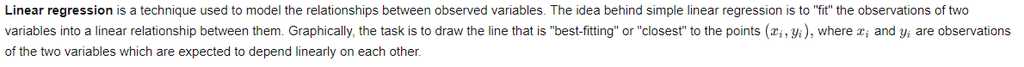

[figure not shown]

### X and y arrays

We'll take TOT-CHL as the y label

```python
import statsmodels.api as sm
```

```python
df.head()
```

|  | Date | TOT-CHL | PH | ASA | RWC | APTI | CARB | PROTEIN | RED-SUG | NON-RED SUGARS | STARCH | TOTAL SUG | PHENOLS | CAT | POD | PPO |
| --- | --- | --- | --- | --- | --- | --- | --- | --- | --- | --- | --- | --- | --- | --- | --- | --- |
| 0 | 2015-11-09 | 0.86 | 0.86 | 1.0 | 87.0 | 9.38 | 61.98 | 36.9 | 0.51 | 3.47 | 50.83 | 3.98 | 67.1 | 632.5 | 95.4 | 225.6 |
| 1 | 2015-12-09 | 1.03 | 1.03 | 0.6 | 81.0 | 8.55 | 60.22 | 36.8 | 0.62 | 3.37 | 50.96 | 3.99 | 67.6 | 632.6 | 93.2 | 225.6 |
| 2 | 2015-01-10 | 0.82 | 0.82 | 0.5 | 80.0 | 8.36 | 62.12 | 36.8 | 0.61 | 3.26 | 50.96 | 3.87 | 67.3 | 632.5 | 93.1 | 225.5 |
| 3 | 2015-02-10 | 0.35 | 0.35 | 0.2 | 66.0 | 6.74 | 61.25 | 36.4 | 0.59 | 3.27 | 51.23 | 3.86 | 67.7 | 632.5 | 93.0 | 225.5 |
| 4 | 2015-03-10 | 0.62 | 0.62 | 0.4 | 60.0 | 6.28 | 62.14 | 36.6 | 0.60 | 3.27 | 51.24 | 3.87 | 67.2 | 632.4 | 93.4 | 225.4 |

```python
df.drop('Date', axis=1).head()
```

|  | TOT-CHL | PH | ASA | RWC | APTI | CARB | PROTEIN | RED-SUG | NON-RED SUGARS | STARCH | TOTAL SUG | PHENOLS | CAT | POD | PPO |
| --- | --- | --- | --- | --- | --- | --- | --- | --- | --- | --- | --- | --- | --- | --- | --- |
| 0 | 0.86 | 0.86 | 1.0 | 87.0 | 9.38 | 61.98 | 36.9 | 0.51 | 3.47 | 50.83 | 3.98 | 67.1 | 632.5 | 95.4 | 225.6 |
| 1 | 1.03 | 1.03 | 0.6 | 81.0 | 8.55 | 60.22 | 36.8 | 0.62 | 3.37 | 50.96 | 3.99 | 67.6 | 632.6 | 93.2 | 225.6 |
| 2 | 0.82 | 0.82 | 0.5 | 80.0 | 8.36 | 62.12 | 36.8 | 0.61 | 3.26 | 50.96 | 3.87 | 67.3 | 632.5 | 93.1 | 225.5 |
| 3 | 0.35 | 0.35 | 0.2 | 66.0 | 6.74 | 61.25 | 36.4 | 0.59 | 3.27 | 51.23 | 3.86 | 67.7 | 632.5 | 93.0 | 225.5 |
| 4 | 0.62 | 0.62 | 0.4 | 60.0 | 6.28 | 62.14 | 36.6 | 0.60 | 3.27 | 51.24 | 3.87 | 67.2 | 632.4 | 93.4 | 225.4 |

```python
X = df.drop(['TOT-CHL', 'Date'], axis=1)
y = df['TOT-CHL']
```

```python
print("X.shape:",X.shape)
print("y.shape:",y.shape)
```

```
X.shape: (24, 14)
y.shape: (24,)
```

## Creating and Training the model

```python
from sklearn import linear_model
```

```python
lm = linear_model.LinearRegression()
```

```python
model = lm.fit(X, y)
```

## Model Evaluation

```python
predictions = lm.predict(X)
```

```python
from sklearn import metrics
```

```python
print('MAE:', metrics.mean_absolute_error(y, predictions))
print('MSE:', metrics.mean_squared_error(y, predictions))
print('RMSE:', np.sqrt(metrics.mean_squared_error(y, predictions)))
```

```
MAE: 0.14772106484229602
MSE: 0.03716207319951905
RMSE: 0.1927746694965888
```

```python
model.score(X, y)
```

```
0.4855817681245501
```

Weight Vector or coefficirnt matrix is given as follows

```python
lm.coef_
```

```
array([ 1.65894369e-01,  1.25495697e+00,  1.50613091e-01, -1.51204862e+00,
       -5.54741224e-02, -9.64933658e-02, -8.05960021e+00, -9.09380187e+00,
        1.82939429e-01,  9.49841877e+00,  1.12573390e-01, -2.24189197e-04,
        1.19789006e-01,  4.18788752e-02])
```

```python
predictions
```

```
array([1.00946629, 0.92861009, 0.69073946, 0.72179123, 0.7444483 ,
       1.04093791, 0.63886975, 0.8766647 , 0.83350647, 0.86663632,
       0.49643781, 0.65276006, 0.86131343, 0.66920241, 0.78021969,
       0.77168164, 0.63563458, 1.17005727, 0.58373542, 0.97638444,
       0.70207155, 1.20963204, 0.7697514 , 0.46944777])
```

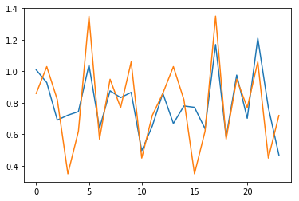

```python
plt.plot(predictions)
plt.plot(y)
```

48.5% accuracy suggests that the data is not linearly seperable and we cannot predict value of TOT-CHL with certainity with other given parameters using Linear Regression

# PCA

Principal Component Analysis

## Standardising the Data

PCA is effected by scale so you need to scale the features in your data before applying PCA. Use StandardScaler to help you standardize the dataset’s features onto unit scale (mean = 0 and variance = 1) which is a requirement for the optimal performance of many machine learning algorithms.

```python
from sklearn.preprocessing import StandardScaler
```

```python
features = []
for i in df1.columns:
    features.append(i)
```

```python
features.remove('TOT-CHL')
```

```python
features.remove('Date')
```

```python
features
```

[output not shown]

```python
X = df1.loc[:,features].values
```

```python
X = StandardScaler().fit_transform(X)
```

## Elbow Method

We will use elbow method to find optimum number of clusters

```python
import pylab as pl
from sklearn.preprocessing import MinMaxScaler
from sklearn.cluster import KMeans
```

```python
X = df1.drop(['TOT-CHL', 'Date'], axis=1)
```

```python
Nc = range(1,20)
kmeans = [KMeans(n_clusters=1) for i in Nc]
```

```python
X.describe()
```

[output not shown]

```python
mms = MinMaxScaler()
mms.fit(X)
data_transformed = mms.transform(X)
```

```python
Sum_of_squared_distances = []
K = range(1,15)
for k in K:
    km = KMeans(n_clusters=k)
    km = km.fit(data_transformed)
    Sum_of_squared_distances.append(km.inertia_)
```

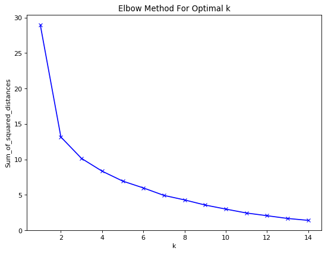

```python
from matplotlib.pyplot import figure
figure(num=None, figsize=(8, 6), dpi=80, facecolor='w', edgecolor='k')

plt.plot(K, Sum_of_squared_distances, 'bx-')
plt.xlabel('k')
plt.ylabel('Sum_of_squared_distances')
plt.title('Elbow Method For Optimal k')
plt.show()
```

## PCA components

```python
from sklearn.decomposition import PCA
```

```python
def do_pca(n_components,data):
    X = StandardScaler().fit_transform(data)
    pca = PCA(n_components)
    X_pca = pca.fit_transform(X)
    return pca, X_pca
```

```python
pca, X_pca = do_pca(4, X)
```

```python
X_pca.shape
```

```
(24, 4)
```

```python
principalDf = pd.DataFrame(data = X_pca
             , columns = ['principal component 1', 'principal component 2',
                         'principal component 3', 'principal component 4'])
```

```python
finalDf = pd.concat([principalDf, df[['PH']]], axis = 1)
```

```python
finalDf.head()
```

|  | principal component 1 | principal component 2 | principal component 3 | principal component 4 | PH |
| --- | --- | --- | --- | --- | --- |
| 0 | 0.992609 | 1.517358 | 2.450457 | -1.076585 | 0.86 |
| 1 | 2.735923 | 2.275781 | -0.271377 | -1.119011 | 1.03 |
| 2 | 2.414833 | 2.016069 | -0.384428 | -0.652614 | 0.82 |
| 3 | 2.818638 | 1.163729 | -0.396215 | -0.383804 | 0.35 |
| 4 | 2.231163 | 0.877619 | -0.525122 | -0.311801 | 0.62 |

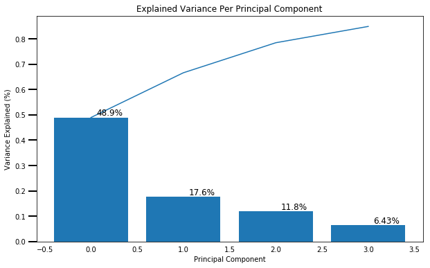

```python
def scree_plot(pca):
    '''
    Creates a scree plot associated with the principal components

    INPUT: pca - the result of instantian of PCA in scikit learn

    OUTPUT:
            None
    '''
    num_components = len(pca.explained_variance_ratio_)
    ind = np.arange(num_components)
    vals = pca.explained_variance_ratio_

    plt.figure(figsize=(10, 6))
    ax = plt.subplot(111)
    cumvals = np.cumsum(vals)
    ax.bar(ind, vals)
    ax.plot(ind, cumvals)
    for i in range(num_components):
        ax.annotate(r"%s%%" % ((str(vals[i]*100)[:4])), (ind[i]+0.2, vals[i]), va="bottom", ha="center", fontsize=12)

    ax.xaxis.set_tick_params(width=0)
    ax.yaxis.set_tick_params(width=2, length=12)

    ax.set_xlabel("Principal Component")
    ax.set_ylabel("Variance Explained (%)")
    plt.title('Explained Variance Per Principal Component')


scree_plot(pca)
```

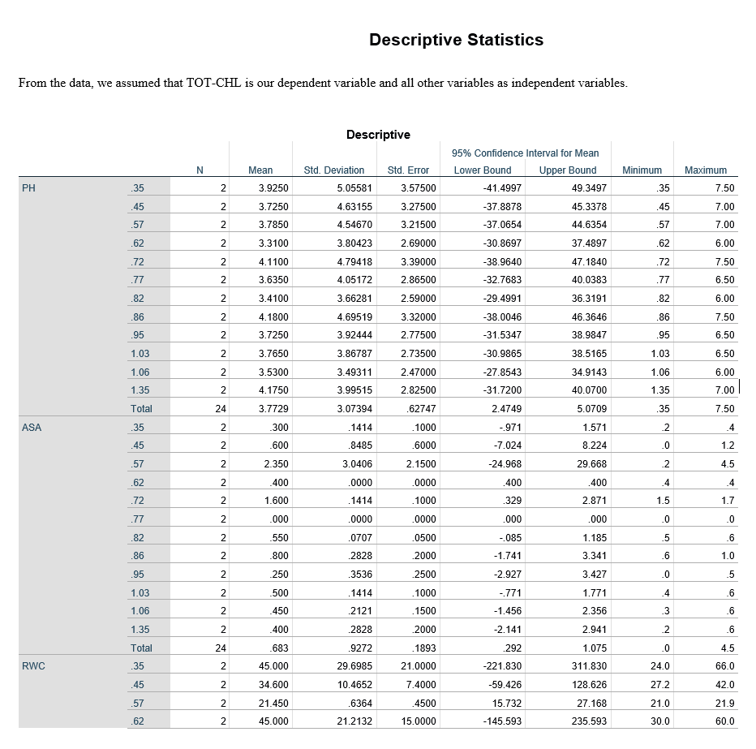

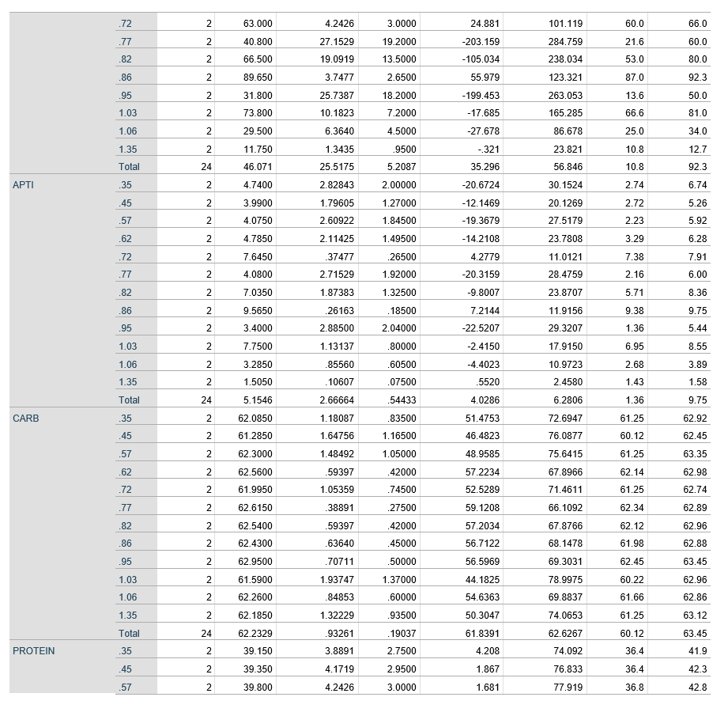

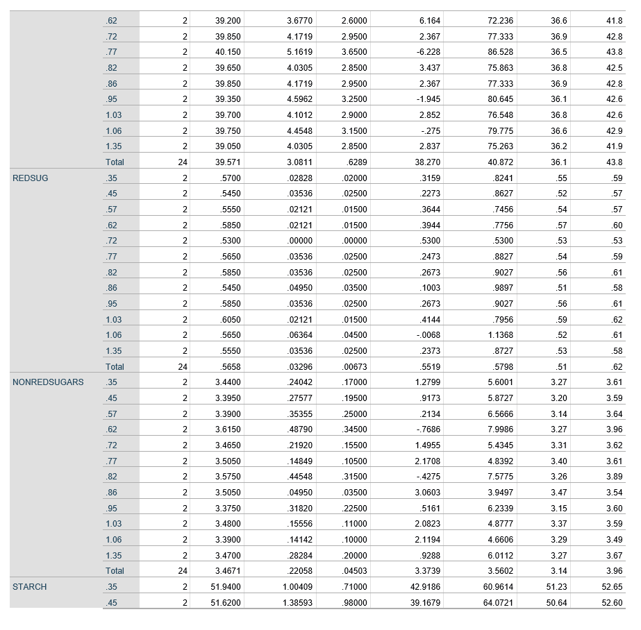

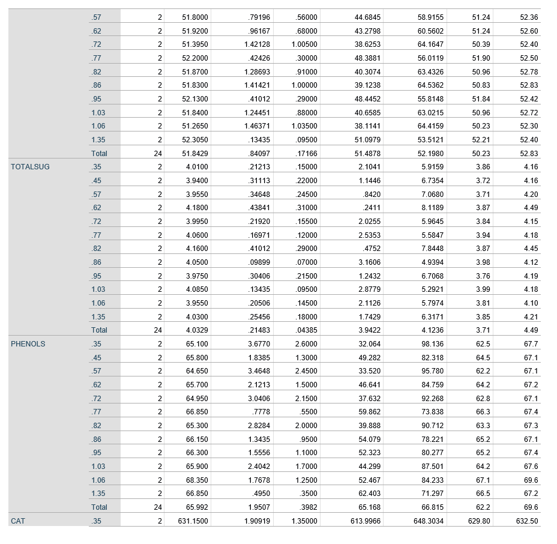

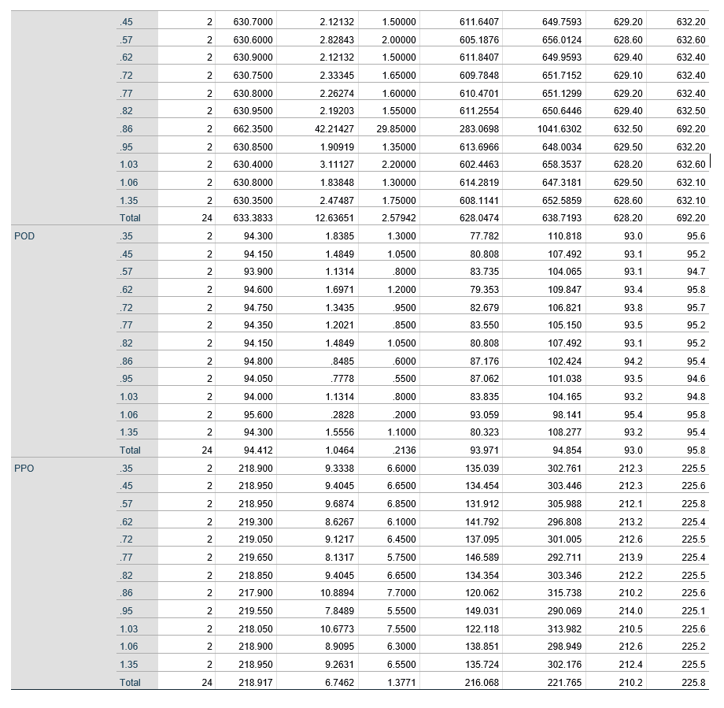

# ANOVA

An ANOVA test is a way to find out if survey or experiment results are significant. In other words, they help you to figure out if you need to reject the null hypothesis or accept the alternate hypothesis. Basically, you’re testing groups to see if there’s a difference between them.

When to use a one way ANOVA

Situation 1: You have a group of individuals randomly split into smaller groups and completing different tasks. For example, you might be studying the effects of tea on weight loss and form three groups: green tea, black tea, and no tea.

Situation 2: Similar to situation 1, but in this case the individuals are split into groups based on an attribute they possess. For example, you might be studying leg strength of people according to weight. You could split participants into weight categories (obese, overweight and normal) and measure their leg strength on a weight machine.

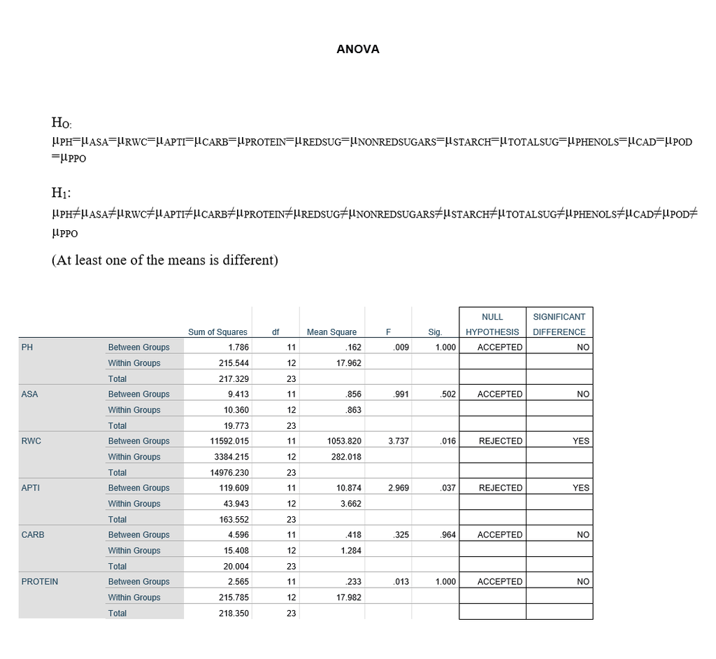

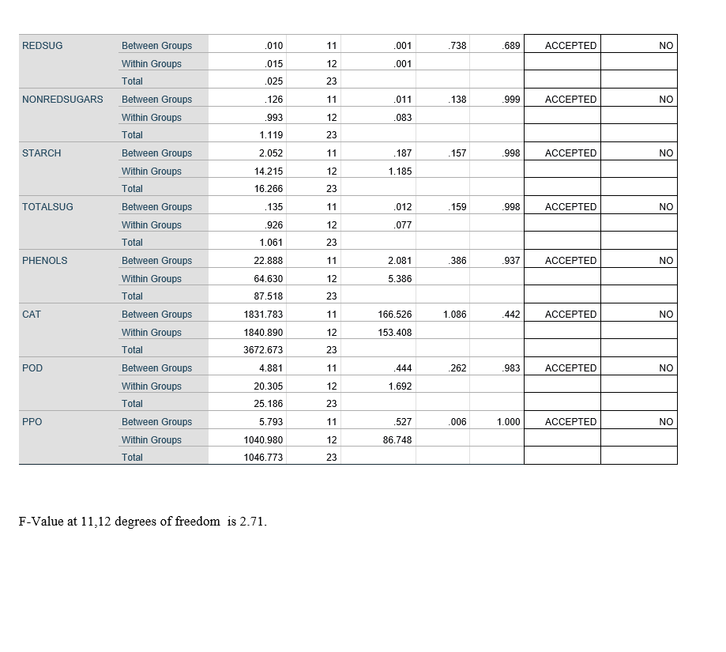

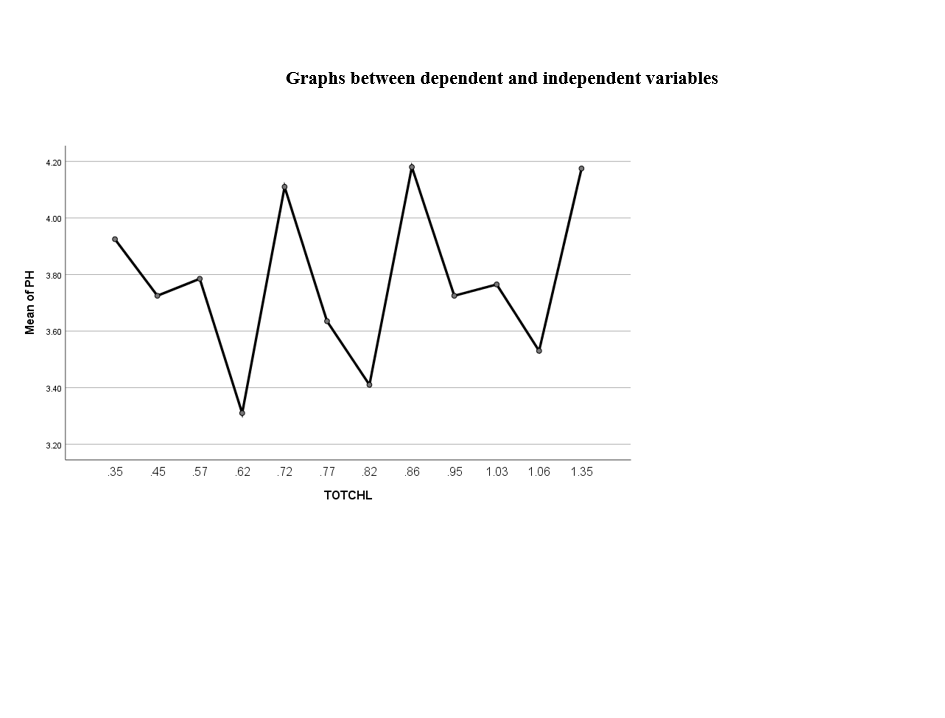

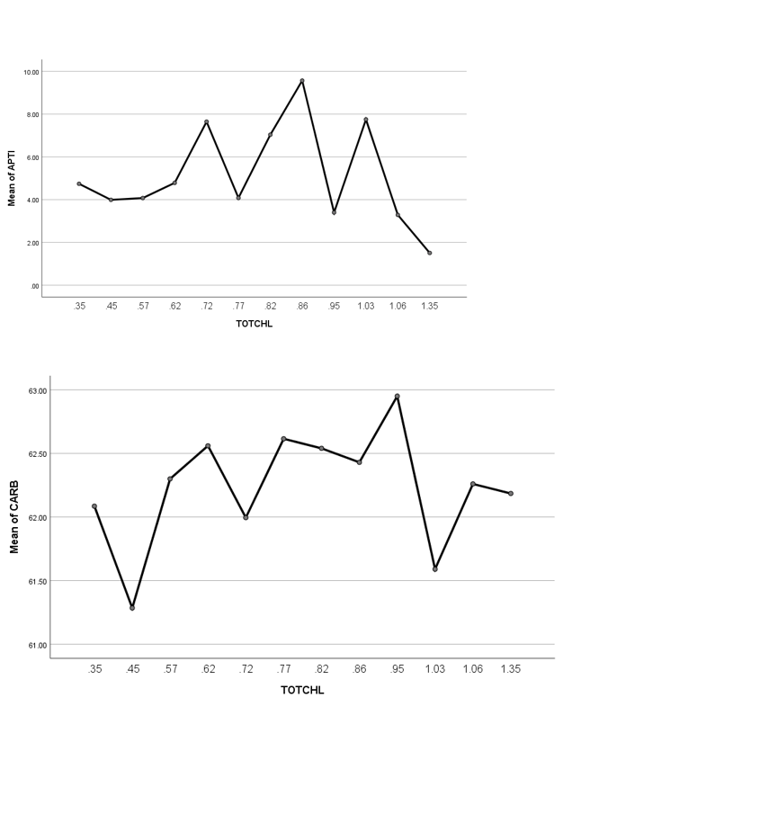

[figure not shown]

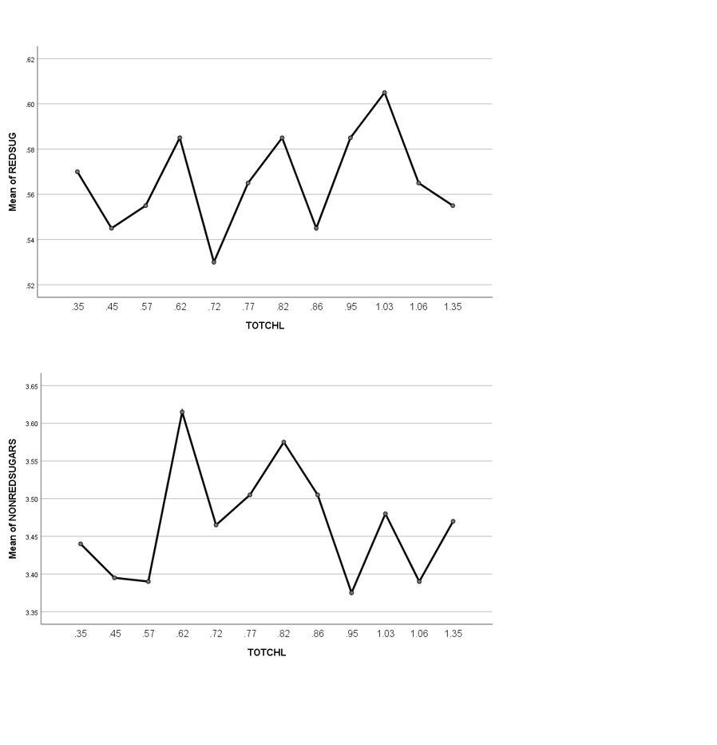

[figure not shown]

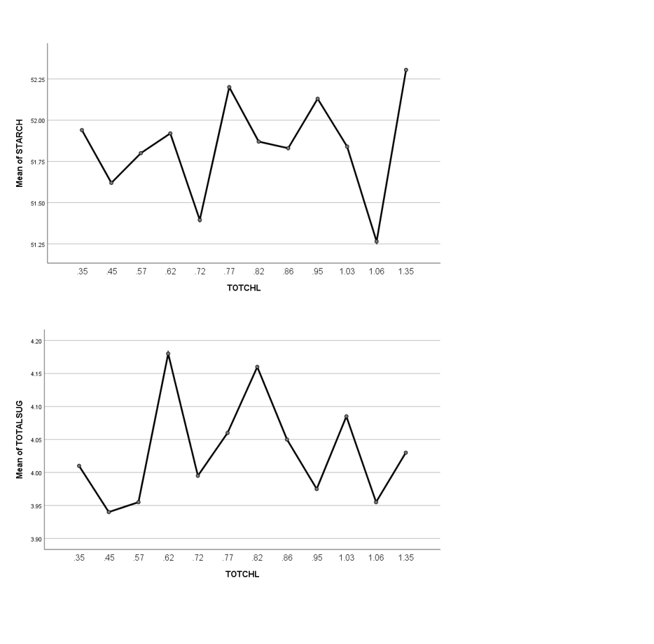

[figure not shown]

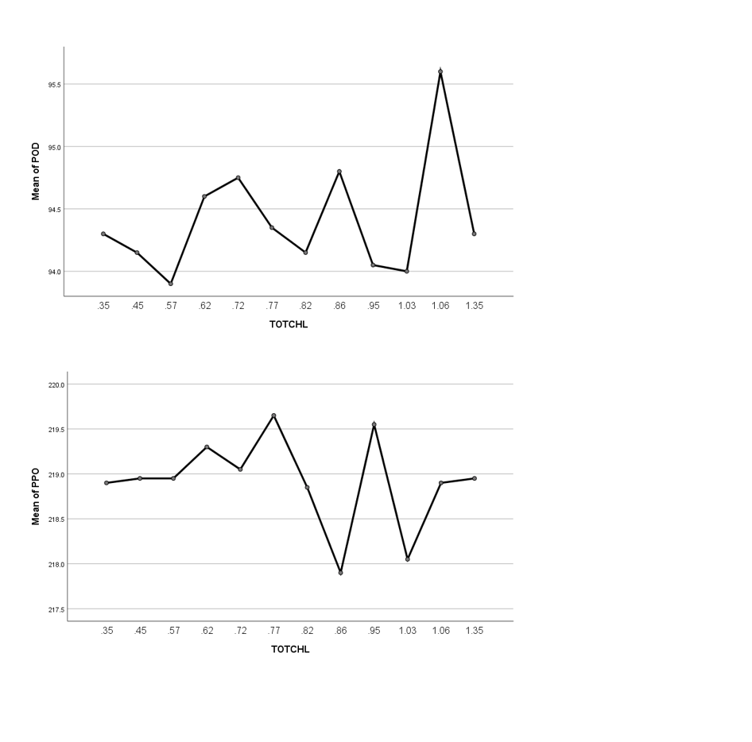

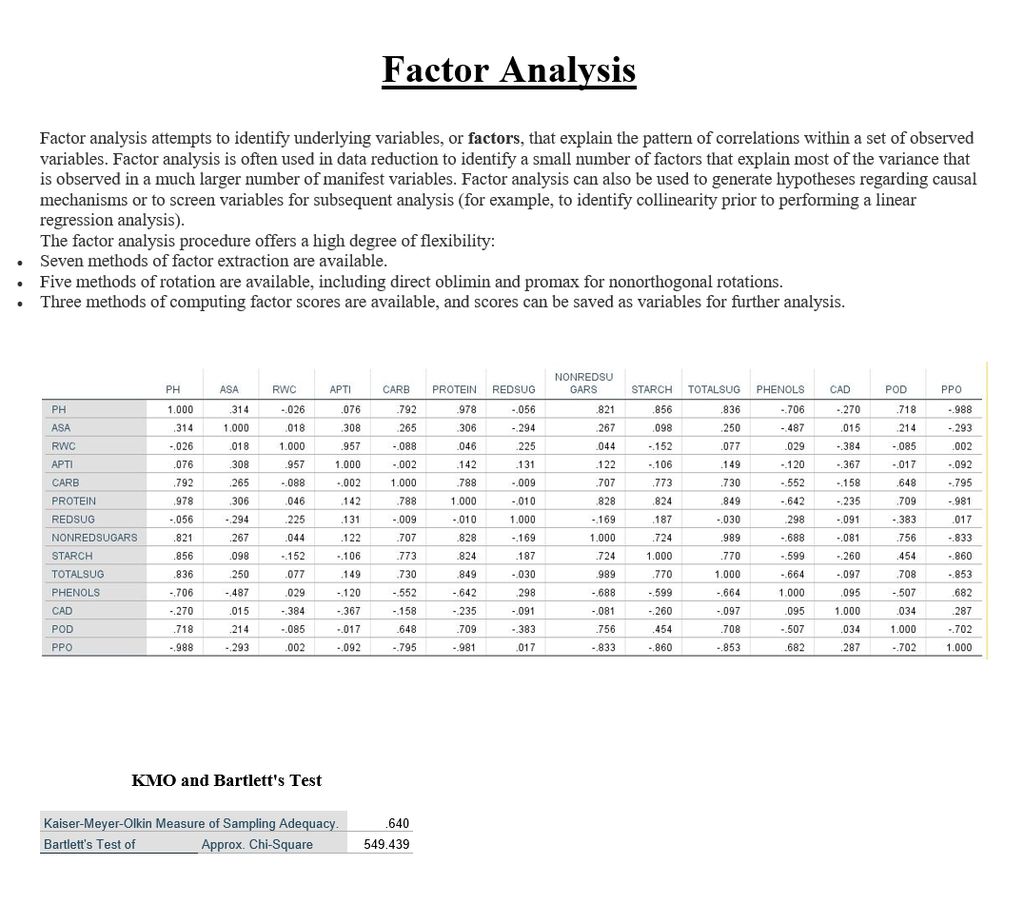

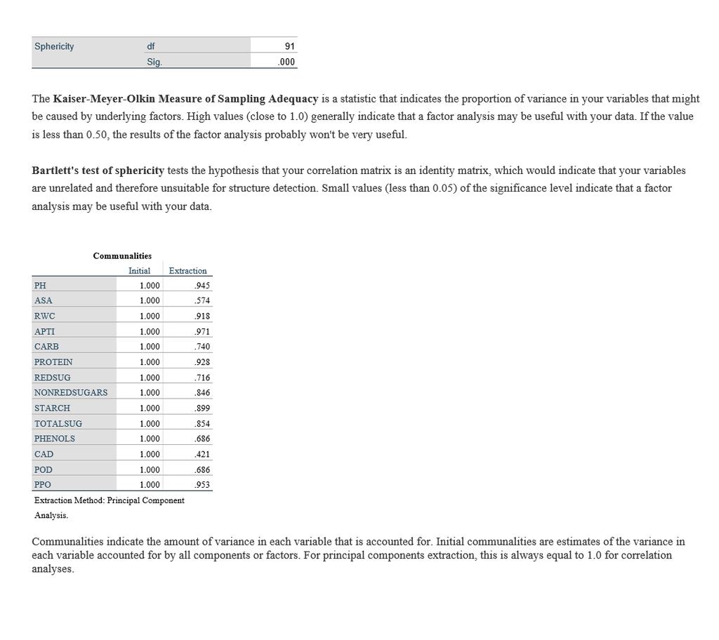

[3 more figures not shown]